# Assignment 3: Data Distributions & Linear Models

## Challenge 2

> Create a histogram for the column of temperature data.  
> What kind of distribution do the temperature data most closely follow?  
> What is the mean temperature over the entire study period?  
> What is the mean temperature for the month of August?  
> What is the mean temperature for the month of June?

**Toggle answer**

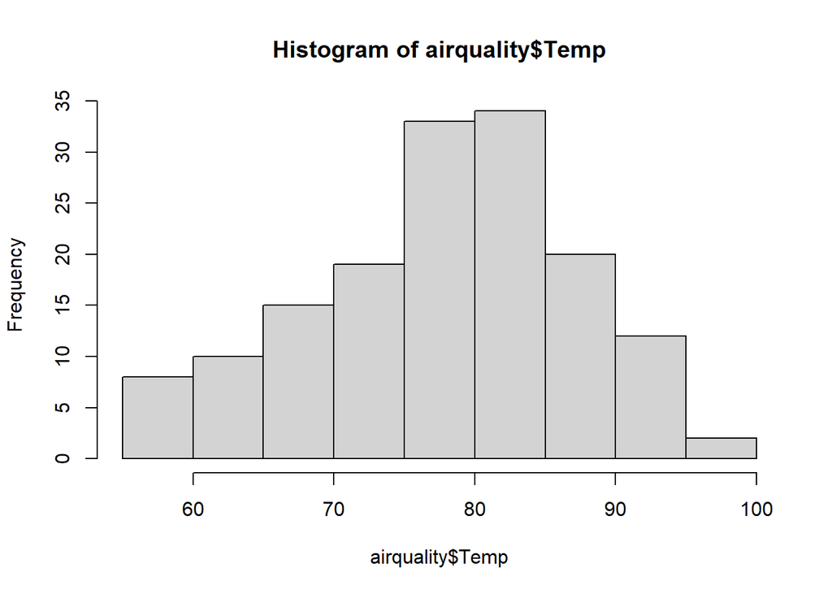

```r
# Create a histogram for temperature data
hist(airquality$Temp)
```

```r
# Calculate mean temperature over entire study period
mean(airquality$Temp, na.rm = T)
```

```
## [1] 77.88235
```

```r
# Calculate mean temperature for the month of August
# (Hint: We already created a data frame that contains only August data)
mean(aug$Temp, na.rm = T)
```

```
## [1] 83.96774
```

```r
# Create data frame that contains only data collected in June
jun <- airquality[airquality$Month_Name == "June",]
# Calculate mean of Temp column in jun data frame
mean(jun$Temp, na.rm = T)
```

```
## [1] 79.1
```

## Boxplots

You can also compare the distribution of a variable across multiple groups using the function `boxplot()`.  
The form of the function is `boxplot(DepVar ~ GroupVar, data = dataobject)`.  
Let’s use this function to create a boxplot showing the variation in Ozone concentrations by month:

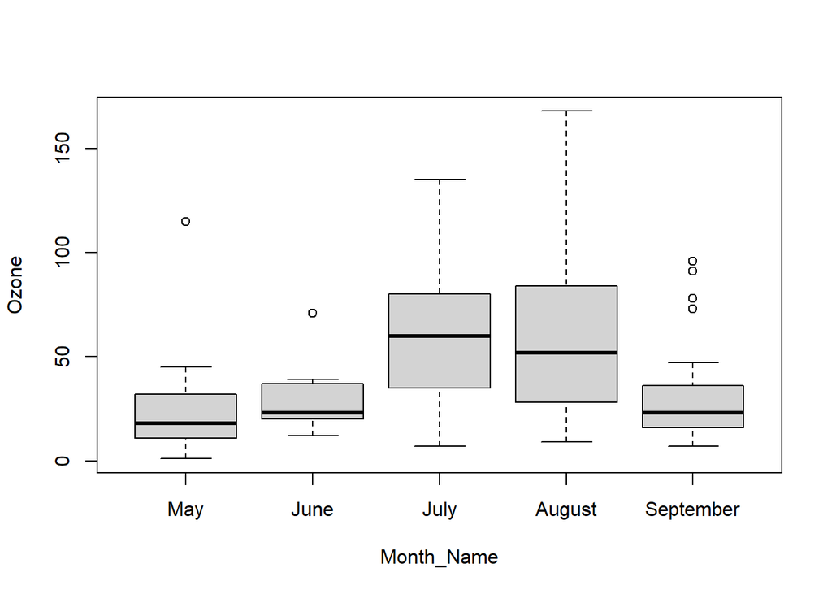

```r
# Create boxplot
boxplot(Ozone~Month_Name, data = airquality)
```

Now compare this boxplot to one that plots your log10-transformed Ozone variable.  
Note that additional arguments have been added to the boxplot function to rename axes.

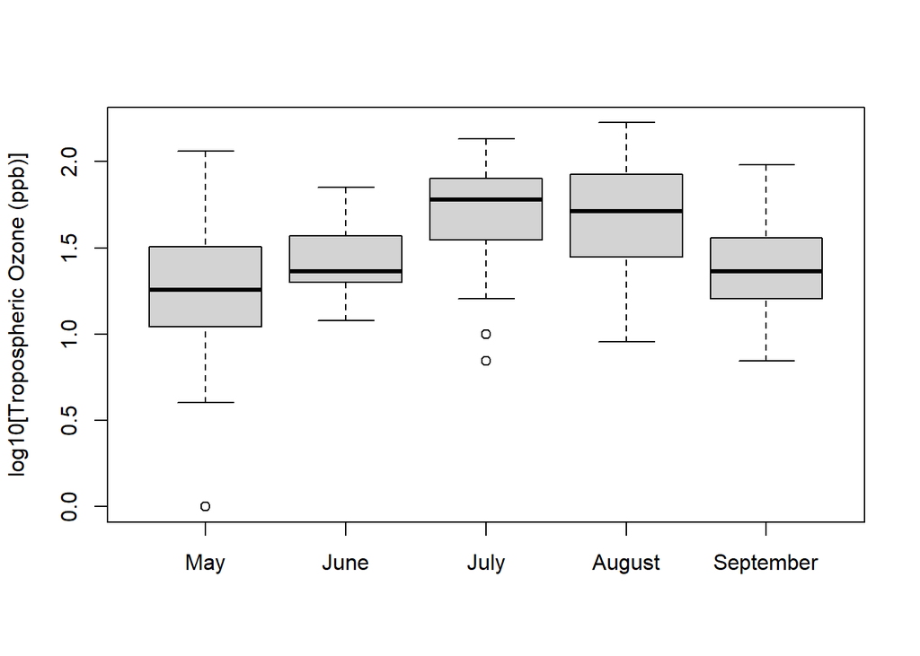

```r
# Create boxplot for log10-transformed ozone variable
boxplot(log10(Ozone)~Month_Name,
        data = airquality,
        xlab = NULL,
        ylab = "log10[Tropospheric Ozone (ppb)]")
```

## Challenge 3

> Compare the boxplot of your untransformed Ozone variable to your log10-transformed Ozone variable.  
> Did this transformation improve the distribution of ozone observations within groups? (Hint: Are the distributions more symmetrical?)  
> Did this transformation improve the homogeneity of variances among groups? (Hint: Do error bars look more similar among groups?)

# Comparing Groups using Analysis of Variance (ANOVA)

Once you have established that your data meet the assumptions of normality, or you have transformed your data so that they meet the assumptions of normality, you can analyze your data using parametric tests like an **Analysis of Variance (ANOVA)**, **t-test**, or **Analysis of Covariance (ANCOVA)**. Here we would like to compare Ozone concentrations among five months, so we will use the simplest ANOVA function, `aov()`.

The form of the function is `aov(DepVar ~ IndVar, data = data)`  
If you wish to add additional variables and their interactions: `aov(DepVar ~ IndVar1 * IndVar2, data = data)`  
If you wish to add additional variables *without* interactions: `aov(DepVar ~ IndVar1 + IndVar2, data = data)`

## ANOVA model

We can create a new model object and specify the ANOVA formula.  
Then we use the `summary()` function to call the results of the ANOVA:

```r
# ANOVA model
aov1 <- aov(log10(Ozone)~Month_Name, data = airquality)
# Call results of ANOVA
summary(aov1)
```

```
##              Df Sum Sq Mean Sq F value   Pr(>F)
## Month_Name    4  4.033   1.008   9.163 1.96e-06 ***
## Residuals   111 12.214   0.110
## ---
## Signif. codes:  0 '***' 0.001 '**' 0.01 '*' 0.05 '.' 0.1 ' ' 1
## 37 observations deleted due to missingness
```

## Post-hoc tests

If we want to know *which months* differ from each other, we can use a post-hoc test such as **Tukey’s Honestly Significant Difference (Tukey HSD)**.

```r
# Run Tukey post-hoc comparisons for ANOVA model
TukeyHSD(aov1)
```

```
##   Tukey multiple comparisons of means
##     95% family-wise confidence level
##
## Fit: aov(formula = log10(Ozone) ~ Month_Name, data = airquality)
##
## $Month_Name
##                          diff         lwr         upr     p adj
## June-May          0.184400319 -0.17136565  0.54016629 0.6050267
## July-May          0.465458802  0.21032580  0.72059180 0.0000164
## August-May        0.448743151  0.19361015  0.70387615 0.0000352
## September-May     0.176635722 -0.07181141  0.42508285 0.2867042
## July-June         0.281058483 -0.07470749  0.63682445 0.1908453
## August-June       0.264342831 -0.09142314  0.62010880 0.2447291
## September-June   -0.007764598 -0.35876681  0.34323762 0.9999967
## August-July      -0.016715652 -0.27184865  0.23841735 0.9997526
## September-July   -0.288823081 -0.53727021 -0.04037595 0.0140810
## September-August -0.272107429 -0.52055456 -0.02366030 0.0243361
```

## Challenge 4

> Interpret the results of your ANOVA and posthoc tests:  
> What is the F-value for your ANOVA?  
> What is the p-value for your ANOVA?  
> Does ozone concentration differ significantly among months?  
> If yes, which pairs of months are significantly different?

# Linear Regression

Once you have established that your data meet the assumptions of normality, or you have transformed your data so that they meet the assumptions of normality, you can analyze your data using a linear regression model. For example, we know that tropospheric ozone responds to temperature, so I may want to test for a linear relationship between these two variables.

## Scatterplots

I typically like to plot my variables first. You can create a scatterplot using base graphics using the `plot()` function.

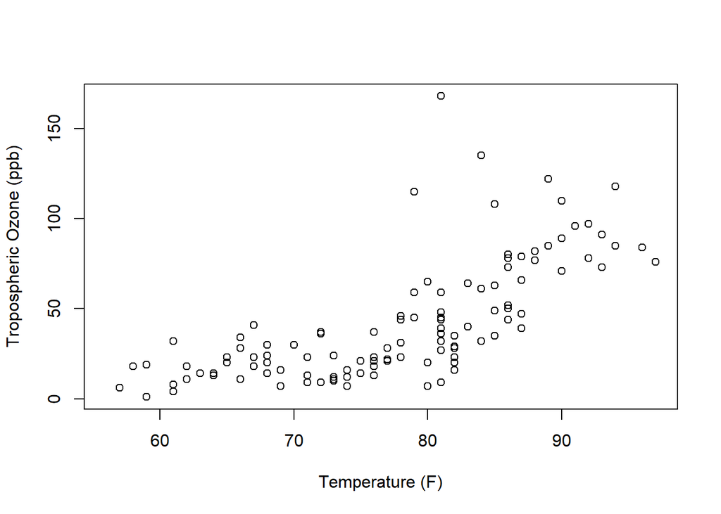

```r
# Plot temperature and ozone
plot(x = airquality$Temp,
     y = airquality$Ozone,
     xlab = "Temperature (F)",
     ylab = "Tropospheric Ozone (ppb)")
```

## Challenge 5

> Create a similar scatterplot for your log10-transformed ozone data.  
> Which lines of the plot code do you need to change to plot your transformed data?  
> How does the transformation change the shape of the relationship?

**Toggle answer**

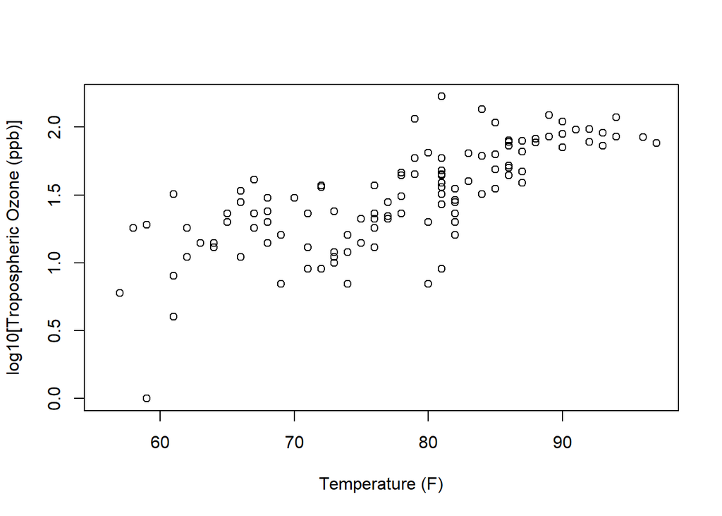

```r
# Plot temperature and log10-transformed ozone
plot(x = airquality$Temp,
     y = log10(airquality$Ozone),
     xlab = "Temperature (F)",
     ylab = "log10[Tropospheric Ozone (ppb)]")
```

## Running Linear Models

Let’s say we wish to run a **linear regression** to test for a relationship between temperature and ozone concentration. We can use the `lm()` function to specify our model.  
The form of the function is `lm(DepVar~IndVar, data = data)`  
We can create a new model object and specify the linear model.  
Then we use the `summary()` function to call the results of the linear regression:

```r
# Linear model
mod1 <- lm(Ozone~Temp, data = airquality)
# Call results of linear model
summary(mod1)
```

```
##
## Call:
## lm(formula = Ozone ~ Temp, data = airquality)
##
## Residuals:
##     Min      1Q  Median      3Q     Max
## -40.729 -17.409  -0.587  11.306 118.271
##
## Coefficients:
##              Estimate Std. Error t value Pr(>|t|)
## (Intercept) -146.9955    18.2872  -8.038 9.37e-13 ***
## Temp           2.4287     0.2331  10.418  < 2e-16 ***
## ---
## Signif. codes:  0 '***' 0.001 '**' 0.01 '*' 0.05 '.' 0.1 ' ' 1
##
## Residual standard error: 23.71 on 114 degrees of freedom
##   (37 observations deleted due to missingness)
## Multiple R-squared:  0.4877, Adjusted R-squared:  0.4832
## F-statistic: 108.5 on 1 and 114 DF,  p-value: < 2.2e-16
```

## Including Transformed Variables

But we know that our Ozone variable is not normally distributed. We can run the same model for our log10-transformed variable.

```r
# Linear model for log10-transformed ozone
mod2 <- lm(log10(Ozone)~Temp, data = airquality)
# Call results of linear model
summary(mod2)
```

```
##
## Call:
## lm(formula = log10(Ozone) ~ Temp, data = airquality)
##
## Residuals:
##      Min       1Q   Median       3Q      Max
## -0.93143 -0.14373  0.01286  0.15855  0.64893
##
## Coefficients:
##              Estimate Std. Error t value Pr(>|t|)
## (Intercept) -0.798220   0.195866  -4.075 8.53e-05 ***
## Temp         0.029316   0.002497  11.741  < 2e-16 ***
## ---
## Signif. codes:  0 '***' 0.001 '**' 0.01 '*' 0.05 '.' 0.1 ' ' 1
##
## Residual standard error: 0.254 on 114 degrees of freedom
##   (37 observations deleted due to missingness)
## Multiple R-squared:  0.5473, Adjusted R-squared:  0.5434
## F-statistic: 137.8 on 1 and 114 DF,  p-value: < 2.2e-16
```

## Challenge 6

> Interpret the results of the two linear regressions:  
> What is the R<sup>2</sup> value for the first regression (including the untransformed ozone variable)?  
> What is the slope of the first regression (including the untransformed ozone variable)?  
> What is the R<sup>2</sup> value for the second regression (including the log10-transformed ozone variable)?  
> What is the slope of the second regression (including the log10-transformed ozone variable)?  
> Is there a significant relationship between temperature and ozone concentration?

## Adding Trend lines to Scatterplots

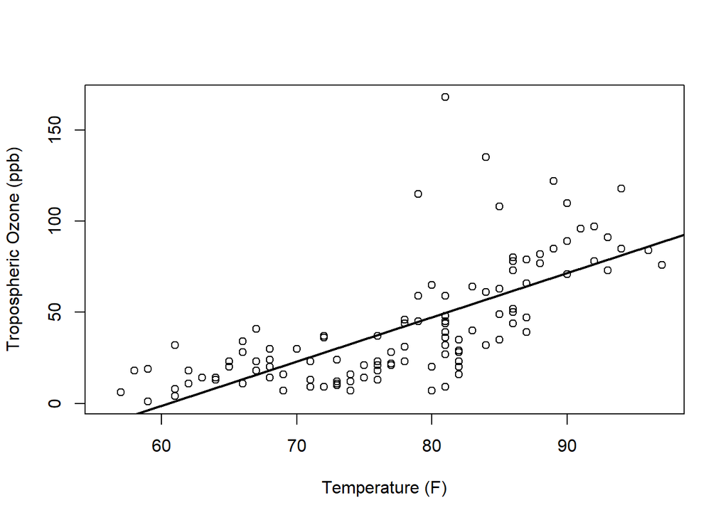

```r
# Create base plot
plot(x = airquality$Temp,
     y = airquality$Ozone,
     xlab = "Temperature (F)",
     ylab = "Tropospheric Ozone (ppb)")
# Add trend line, using linear regression mod2
# Argument lwd used to increase width of trend line
abline(mod1, lwd = 2)
```

## Challenge 7

> Create a similar scatterplot for your log10-transformed ozone data.  
> Be sure to add appropriate axis labels, as well as the trendline for the appropriate model.  
> Consult the “R Base Graphics Cheatsheet” (available on Brightspace) to change one other feature of your graph. Export your final graph by clicking “Export” in the Plots panel, and saving your plot as a .jpg.

**Toggle answer**

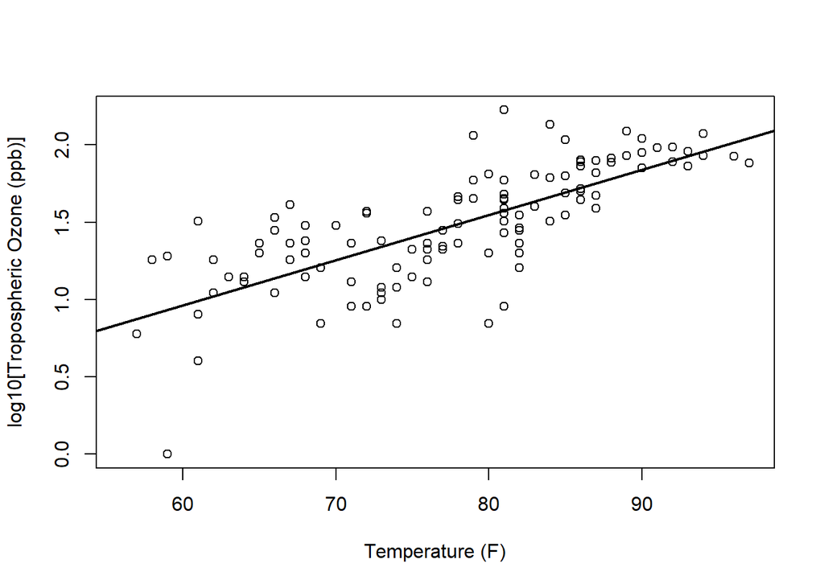

```r
# Create base plot
plot(x = airquality$Temp,
     y = log10(airquality$Ozone),
     xlab = "Temperature (F)",
     ylab = "log10[Tropospheric Ozone (ppb)]")
# Add trend line, using linear regression mod2
# Argument lwd used to increase width of trend line
abline(mod2, lwd = 2)
```

# Checking Distribution of Model Residuals

Though transforming variables to meet the assumptions of linear models is generally good practice, linear models are robust to most violations of these assumptions. The most important thing is that **residual error** in your model is normally distributed. That means that your model does equally well explaining variance across the range of observations that you collected. If a model performs better at one end of the relationship than the other, that could present a problem for any predictions you make based on the model. Let’s use the `hist()` function to check the distribution of residual error in our model of temperature and ozone:

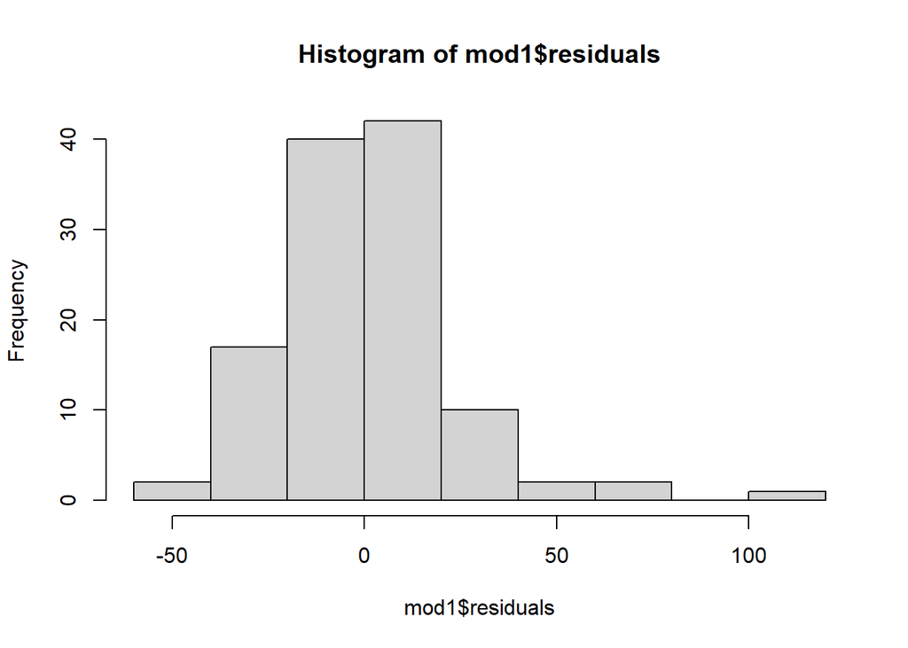

```r
# Plot model residuals
hist(mod1$residuals)
```

…so that doesn’t look great. This distribution is right-skewed. Let’s inspect the distribution of residual error for our model of temperature and log10-transformed ozone:

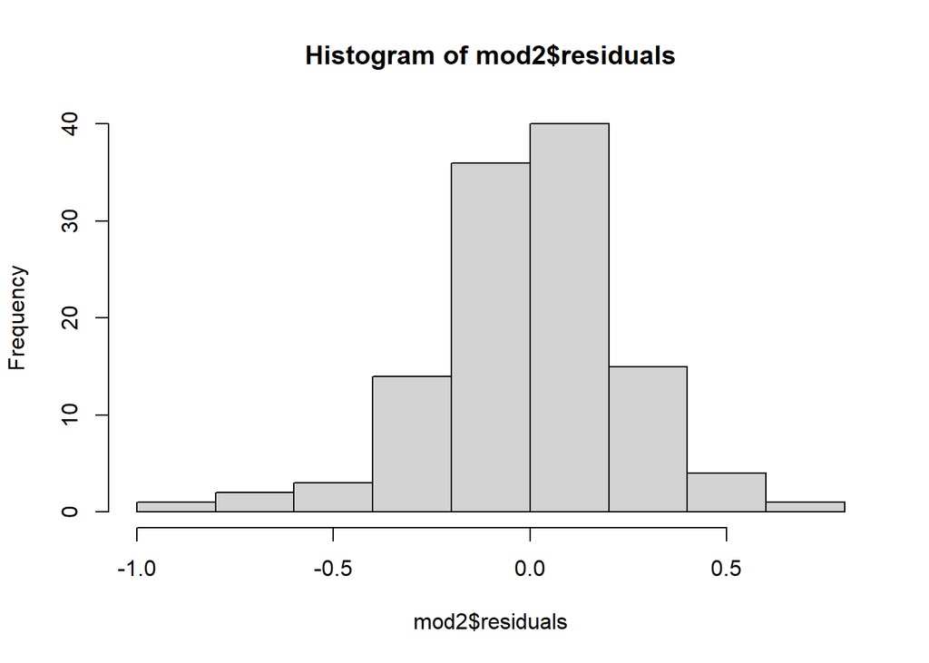

```r
# Plot model residuals
hist(mod2$residuals)
```

This looks better. The model containing our log10-transformed ozone variable results in a more normal distribution of model residuals. When running a linear model, always remember to check that residuals are normally distributed. For small datasets, visual inspection using a histogram works well. For much larger datasets, you may want use statistical techniques like a Lillifors test to determine whether your distribution differs significantly from a normal distribution.